# Review 2: Stats

By Matt Waite

To tell a good story, we need good numbers. The best stories reveal things we don’t know. Often, that means generating your own stats. Let’s walk through a handful of them:

```r
library(tidyverse)
players <- read_csv("~/Box/NCAABasketballData/players19.csv")
```

#### Basic stats: Counts, Averages, Medians

The most basic stats are simple aggregates: counts, averages, medians, percentages of the whole. So let’s look at the makeup of college basketball teams. First question: How many players at each position are there?

You can do a lot with group by, count and mutate

```r
players %>%
  group_by(Pos) %>%
  summarize(total = n())
```

| Pos | total |
| --- | --- |
| C | 294 |
| F | 1966 |
| G | 3125 |
| PF | 1 |

What about percentages?

```r
players %>%
  group_by(Pos) %>%
  summarize(total = n()) %>%
  mutate(percent = (total/nrow(players))*100)
```

| Pos | total | percent |
| --- | --- | --- |
| C | 294 | 5.45859636 |
| F | 1966 | 36.50204233 |
| G | 3125 | 58.02079465 |
| PF | 1 | 0.01856665 |

What about finding teams that are guard heavy? The first thing we need to know is how many players are on each team. Then we can calculate the percent of guards.

```r
players %>%
  group_by(Team) %>%
  tally()
```

| Team | n |
| --- | --- |
| Abilene Christian Wildcats | 15 |
| Air Force Falcons | 18 |
| Akron Zips | 16 |
| Alabama A&M Bulldogs | 15 |
| Alabama Crimson Tide | 16 |
| Alabama State Hornets | 14 |
| Alabama-Birmingham Blazers | 15 |
| Albany (NY) Great Danes | 15 |
| Alcorn State Braves | 17 |
| American Eagles | 15 |

[output cut: 343 more lines]

So now we need to make that a dataframe, then join it to our player data. At first, let’s look at teams that are really heavy on guards.

```r
totalplayers <- players %>% group_by(Team) %>% tally()

players %>%
  group_by(Team, Pos) %>%
  summarize(total = n()) %>%
  left_join(totalplayers, by="Team") %>%
  mutate(percent = (total/n)*100) %>%
  filter(Pos == "G" & percent > 70)
```

| Team | Pos | total | n | percent |
| --- | --- | --- | --- | --- |
| Alabama A&M Bulldogs | G | 11 | 15 | 73.33333 |
| Alabama State Hornets | G | 10 | 14 | 71.42857 |
| Baylor Bears | G | 13 | 16 | 81.25000 |
| Columbia Lions | G | 12 | 16 | 75.00000 |
| Creighton Bluejays | G | 10 | 14 | 71.42857 |
| Eastern Washington Eagles | G | 13 | 18 | 72.22222 |
| George Mason Patriots | G | 12 | 16 | 75.00000 |
| Jackson State Tigers | G | 15 | 21 | 71.42857 |
| Jacksonville Dolphins | G | 12 | 16 | 75.00000 |
| Morgan State Bears | G | 10 | 14 | 71.42857 |

[output cut: 16 more lines]

What does the average team look like?

```r
players %>%
  group_by(Team, Pos) %>%
  summarize(total = n()) %>%
  group_by(Pos) %>%
  summarize(meanpos = mean(total))
```

| Pos | meanpos |
| --- | --- |
| C | 1.492386 |
| F | 5.569405 |
| G | 8.852691 |
| PF | 1.000000 |

But the question remains: Does this matter? Let’s save our percent of guards data to a dataframe so we can find out.

```r
guards <- players %>%
  group_by(Team, Pos) %>%
  summarize(total = n()) %>%
  left_join(totalplayers, by="Team") %>%
  mutate(percent = (total/n)*100) %>%
  filter(Pos == "G")
```

#### Linear regression

So the old saw in college basketball is that if you have good guards, you’ll do well in the tournament. You can make the argument that the more guards you have, the better chance you have to get good guard play. So a question to ask is if the proportion of guards on a team equates to wins.

First we’re going to import gamelogs, clean up the wins column, group by the team and sum up the wins.

```r
teams <- read_csv("~/Dropbox/SPMC350-Data-Literacy-and-Analytics-in-Sports/logs.csv") %>% mutate(winloss = case_when(
  grepl("W", W_L) ~ 1,
  grepl("L", W_L) ~ 0)
) %>%
  group_by(Team) %>%
  summarize(wins = sum(winloss))
```

Now we’ll make a table that has each team, the number of wins and the proportion of guards.

```r
guardteams <- teams %>% left_join(guards, by="Team")
```

Now we can test this statistically using a linear model. Our assumption is that the percent of guards on a team will have something to say about the number of wins a team has. Does it?

```r
fit <- lm(wins ~ percent, data=guardteams)
summary(fit)
```

```
##
## Call:
## lm(formula = wins ~ percent, data = guardteams)
##
## Residuals:
##      Min       1Q   Median       3Q      Max
## -11.6830  -3.6830  -0.2869   3.3466  12.7013
##
## Coefficients:
##             Estimate Std. Error t value Pr(>|t|)
## (Intercept) 17.75758    1.79470   9.894   <2e-16 ***
## percent     -0.05765    0.03061  -1.883   0.0605 .
## ---
## Signif. codes:  0 '***' 0.001 '**' 0.01 '*' 0.05 '.' 0.1 ' ' 1
##
## Residual standard error: 4.911 on 351 degrees of freedom
## Multiple R-squared:   0.01,  Adjusted R-squared:  0.007184
## F-statistic: 3.547 on 1 and 351 DF,  p-value: 0.06048
```

- First: Look at the adjusted R-squared. Think of it like a percent (so move the decimal two places). Is it a high percentage?
- Second: Look at the p-value. Is it less than .05?

The answer in both cases is … nope.

The R-squared is what percent of the change in wins can be predicted by guard percentage. Answer? Very, very, very little. Less than one percent.

The p-value is a measure of how likely the result is to be just random chance. Less that .05 is seen as a dividing line between not random and probably random. In our case … that variation between wins and guard percentage is likely just random noise.

We can see this clearly in a scatterplot.

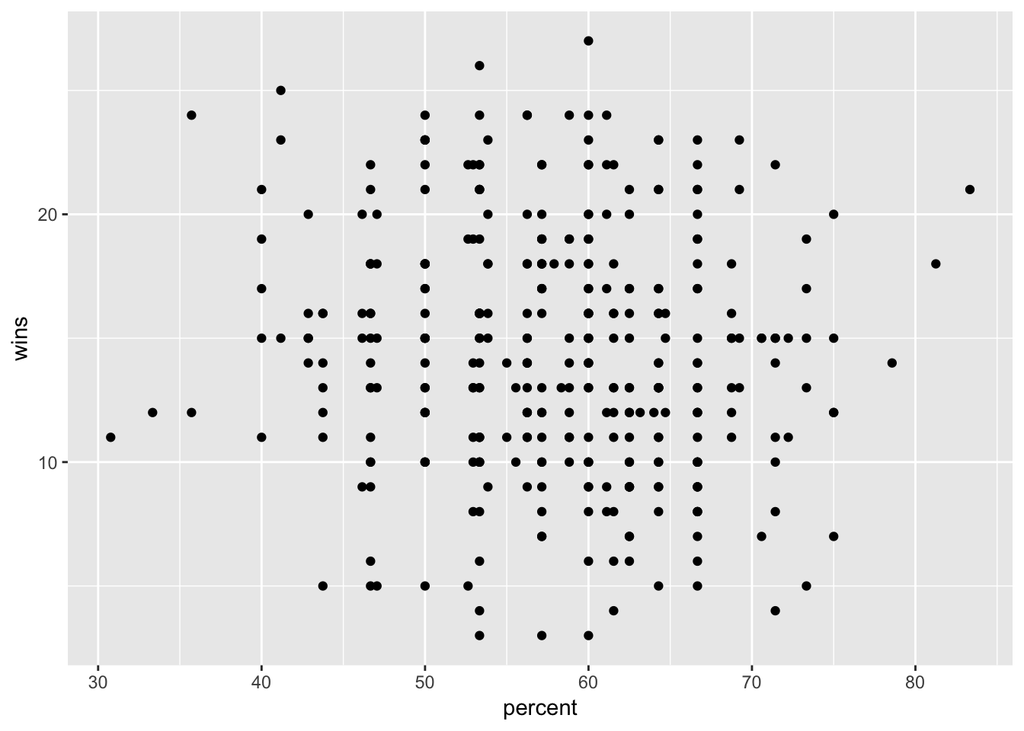

```r
ggplot() + geom_point(data=guardteams, aes(x=percent, y=wins))
```

There’s no pattern here, clearly, so how many guards you have on your team means absolutely nothing when it comes to how many games you’re going to win.

#### Multiple regression

Here’s another silly question: What makes a good rebounder? Does height and weight predict it? There’s some logic to this argument. Are you tall? Are you big and physical? You’re more likely to get rebounds, right?

Let’s test it statistically. First, let’s get us a dataframe that turns height from a character field like “6-1” and turns it into the number of inches a person is tall.

```r
players %>%
  separate(Height, c("Feet", "Inches"), sep="-") %>%
  mutate(Height = (as.numeric(Feet)*12) + as.numeric(Inches)) %>%
  select(Player, Height, Weight, TRB) -> reboundmodel
```

Now we can create the multiple regression model.

```r
fit2 <- lm(TRB ~ Height + Weight, data = reboundmodel)
summary(fit2)
```

```
##
## Call:
## lm(formula = TRB ~ Height + Weight, data = reboundmodel)
##
## Residuals:
##     Min      1Q  Median      3Q     Max
## -148.87  -52.68  -10.18   42.48  294.87
##
## Coefficients:
##               Estimate Std. Error t value Pr(>|t|)
## (Intercept) -208.65447   25.89278  -8.058 9.68e-16 ***
## Height         1.85246    0.44797   4.135 3.61e-05 ***
## Weight         0.71849    0.06285  11.432  < 2e-16 ***
## ---
## Signif. codes:  0 '***' 0.001 '**' 0.01 '*' 0.05 '.' 0.1 ' ' 1
##
## Residual standard error: 67.46 on 4777 degrees of freedom
##   (606 observations deleted due to missingness)
## Multiple R-squared:  0.1052, Adjusted R-squared:  0.1048
## F-statistic: 280.8 on 2 and 4777 DF,  p-value: < 2.2e-16
```

- First: Look at the adjusted R-squared. Think of it like a percent (so move the decimal two places). Is it a high percentage?
- Second: Look at the p-value. Is it less than .05?

Answers? Not really, and oh yeah. So, with this, it means that height and weight can predict about 10 percent of a players rebounding total, and that change is not random. However, are we happy about 10 percent? I’m not. It appears something we can’t measure influences rebounding more.

Or can we?

What if our theory is that rebounding is influenced by hard work? What’s a good proxy for activity? Steals. What happens if we add them in?

```r
players %>%
  separate(Height, c("Feet", "Inches"), sep="-") %>%
  mutate(Height = (as.numeric(Feet)*12) + as.numeric(Inches)) %>%
  select(Player, Height, Weight, TRB, STL) -> reboundmodel2
```

Now we can create the multiple regression model.

```r
fit3 <- lm(TRB ~ Height + Weight + STL, data = reboundmodel2)
summary(fit3)
```

```
##
## Call:
## lm(formula = TRB ~ Height + Weight + STL, data = reboundmodel2)
##
## Residuals:
##     Min      1Q  Median      3Q     Max
## -318.95  -27.95   -5.00   21.09  265.02
##
## Coefficients:
##               Estimate Std. Error t value Pr(>|t|)
## (Intercept) -503.18841   18.49778  -27.20   <2e-16 ***
## Height         5.31622    0.31570   16.84   <2e-16 ***
## Weight         0.60994    0.04379   13.93   <2e-16 ***
## STL            3.23878    0.04546   71.25   <2e-16 ***
## ---
## Signif. codes:  0 '***' 0.001 '**' 0.01 '*' 0.05 '.' 0.1 ' ' 1
##
## Residual standard error: 46.98 on 4776 degrees of freedom
##   (606 observations deleted due to missingness)
## Multiple R-squared:  0.5662, Adjusted R-squared:  0.566
## F-statistic:  2078 on 3 and 4776 DF,  p-value: < 2.2e-16
```